# hw01: Welcome to the Jungle

STAT 385, Spring 2018

Due: Friday, February 9th, 2018 at 11:59 PM

# Overview

Please see the [homework policy](http://stat385.thecoatlessprofessor.com/homework-policy/) for detailed instructions and some grading notes. Failure to follow instructions will result in point reductions. In particular, make sure to commit each exercise as you complete them.

> Hofstadter’s Law: “It always takes longer than you expect, even when you take into account Hofstadter’s Law.”

> — **Douglas Hofstadter**, Gödel, Escher, Bach: An Eternal Golden Braid

## Objectives

The objectives behind this homework assignment are as follows:

- Create an *RMarkdown* document and write using *Markdown* syntax;
- Apply the principles of literate programming by embedding code and describing outcomes;
- Read in data;
- Provide data overviews;
- Clone a `git` Repository;
- Commit and Push changes to a `git` repository;
- Become familiar with the homework procedures of the course.

## Grading

The rubric CAs will use to grade this assignment is:

| Task | pts |
| --- | --- |
| Link to GitHub Repository | 2 |
| Agree to the homework policy | 2 |
| Verifying computing environment is setup | 2 |
| Listing where to get help in person | 2 |
| Writing in *RMarkdown* | 10 |
| Working with Baby Name Data | 10 |
| Exploring the Excellent Teachers list at UIUC | 12 |
| At least one commit per exercise (more is better!) | 5 |
| Commit messages that describe what changed | 5 |
| Total | 50 |

## Note on Markdown

If you need help with markdown syntax, please go to the “Help” menu and select the *Markdown Quick Reference* guide. This will open in the **Help** tab on the *lower-right* corner of *RStudio*. For more examples, please see [the literate programming slides](http://stat385.thecoatlessprofessor.com/lectures/02-literate-programming/02-literate-programming.pdf#page=26) and the [in class examples of writing in *RMarkdown*](https://dl.dropboxusercontent.com/s/djhtvrr2f07uyzi/01-22-2018-rmarkdown-sample.Rmd?dl=0).

# Assignment

## (2 points) Exercise 0: Get aboard the GitHub Bus!

Place a link to your `hw01` GitHub repository here.

## (2 points) Exercise 2: [Help! I need somebody](https://www.youtube.com/watch?v=CTsB-llTzyc)

Please answer:

1. Who is part of the STAT 385 instructional staff?
2. Where are **all** STAT 385’s Office Hours?
3. When do the office hours take place during the week?

Answers to these questions can be found on the main page of the course website:

http://stat385.thecoatlessprofessor.com/

## (2 Points) Exercise 3: Know Thine Environment

Please take screenshots of the following and include them in your *RMarkdown* document:

1. the [RStudio Cloud STAT 385 Workspace](https://rstudio.cloud/spaces/960).
2. the [STAT 385 Discussion Forum](https://github.com/stat385-sp2018/disc/issues)
   - To get access to this forum, we *must* know your GitHub Username.
   - Please fill out this survey: https://goo.gl/forms/n0U7Q87walHvNAhi2
   - Having issues logging in? Please see the [walkthrough guide](http://stat385.thecoatlessprofessor.com/readings/00-google-forms/00-google-forms.html) or the [FAQ entry](http://stat385.thecoatlessprofessor.com/faq/#technical-google-forms)

To take a screenshot press:

- Windows: [`Windows Key` + `PrtScn`](http://windows.microsoft.com/en-us/windows/take-screen-capture-print-screen#take-screen-capture-print-screen=windows-8) or use the [Snipping tool](http://windows.microsoft.com/en-us/windows/use-snipping-tool-capture-screen-shots#1TC=windows-8)
- macOS: [`Command` + `Shift` + `3`](https://support.apple.com/en-us/HT201361) or use [`Command` + `Shift` + `4`](https://support.apple.com/en-us/HT201361) for part of your screen.

## (10 Points) Exercise 4: Who I Am

If you need help with markdown syntax, please go to the “Help” menu and select the *Markdown Quick Reference* guide. This will open in the **Help** tab on the *lower-right* corner of *RStudio*. For more examples, please see [the literate programming slides](http://stat385.thecoatlessprofessor.com/lectures/02-literate-programming/02-literate-programming.pdf#page=26) and the [in class examples of writing in *RMarkdown*](https://dl.dropboxusercontent.com/s/djhtvrr2f07uyzi/01-22-2018-rmarkdown-sample.Rmd?dl=0).

- Create a self-portrait of yourself by either taking a picture or sketching it. Include this self-portrait within the *RMarkdown* document.
  - Make sure to upload and commit your photo!
- Make a 7 by 2 table in markdown that has a header row containing “Overview” and “Who I Am”.
  - Under the “Overview” column, please write entries using bold text for: Full Name, NetID, Birthday, Year in School, Major, and Expected Graduation Date
  - Under the “Who I Am” column, please fill in your personal information.
- Compile **ordered** lists for each of your favorite:
  - foods;
  - TV shows;
  - movies;
  - music (add links to music videos on either YouTube or Vimeo).
- Devise *two* **unordered** lists that contain your most recent memorable events and where you typically spend your free time.
- Write the following formula as an *inline* equation.
  - For help writing in LaTeX, see the following symbol’s guide: https://artofproblemsolving.com/wiki/index.php/LaTeX:Symbols and see [`lab00` solutions](https://github.com/stat385-sp2018/lab00-coatless/blob/master/rmarkdown-examples/rmarkdown-example.Rmd).

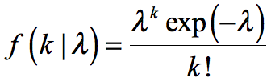

LaTeX Formual

- What is the name of your favorite mathematical formula? Include the formula itself using *display mode* and a link to its wikipedia entry.
  - For inspiration, check out [Wikipedia’s Mathematical Formula list](https://en.wikipedia.org/wiki/List_of_equations)!
  - **Note:** You *cannot* select the pythagorean theorem, golden ratio, or quadratic formula as those were given as examples in [`lab00`](https://github.com/stat385-sp2018/lab00/blob/master/rmarkdown-examples/rmarkdown-example.Rmd).

Commit and push your work onto GitHub.

## (10 Points) Exercise 5: Got baby?

**[2 Points] (a)** Install and load the `babynames` package. **Comment** out the installation command in your `.Rmd` file. (If you do not comment installation commands out, then they will be run every time you knit your `.Rmd` file.)

**[2 Points] (b)** Open up the help documentation for `babynames` (the data set), find where the variables for the data set are listed and write in your *RMarkdown* document *how* the `prop` variable was created.

**[6 Points] (c)** Provide summary information on the `babynames` by:

- writing a sentence that *dynamically* describes the dimensions of the data;
- showing the last six observations in the data set; and,
- providing a summary overview of the data to understand its contents.

## (12 Points) Exercise 6: Excellency at UIUC

Under this exercise, we will explore the “Teachers Ranked As Excellent” data at UIUC from Fall 1993 to Present as compiled by [Wade Fagen-Ulmschneider](http://waf.cs.illinois.edu/). Please download the data from:

https://raw.githubusercontent.com/wadefagen/Teachers-Ranked-As-Excellent-UIUC/master/TRE-UIUC-AllYears.csv

This data has a file extension of **CSV** form. Contained in the data are the following variables:

- `term`: Two letter semester code (`sp`, `su`, `fa`, or `wi`) followed by a four digit year.
  - Examples: `sp2017`, `fa2013`, `su2012`.
- `unit`: The CITL-supplied headers for the unit teaching the course.
  - Examples: `ACCOUNTANCY`, `SOCIAL WORK`, `LINGUISTICS`, `NUCLEAR, PLASMA & RAD. ENGR.`
- `lname`: The last name of the teacher.
  - Examples: `FAGEN-ULMSCHNEIDER`, `FLANAGAN`, `FLECK`
- `fname`: The first letter of the first name of the teacher.
  - Examples: `W`, `K`, `M`
- `role`: `Instructor` or `TA`
- `ranking`: `Excellent` or `Outstanding`
- `course`: The course the teacher was ranked as excellent. If no course is given, the `course` field is set to `?` (this includes cases when the raw data lists the course as `0`, `000`, or `999`).
  - Examples: `199`, `225`, `560`, `?`

**[2 points] (a)** Import into *R* the data in `TRE-UIUC-AllYears.csv` with the variable name `tre_data`. As `course` contains a value that is *not* `NA`, which is how *R* represents missing values, you must use the parameter `na.strings = c("?", "NA")` in the appropriate `read.*()` function. If you need help, please see the appropriate help documentation via `?`.

**NB** The `*` in the `read.*()` statement is a placeholder for the type of file you want to read in.

**[2 points] (b)** Retrieve the dimensional information for this data using only one function.

**[4 points] (c)** Perform a summary of the `tre_data`. Are there any summaries that are surprising? What might have caused this?

*Hint* Consider looking at the structure of `tre_data`.

**[4 points] (d)** Fix the following code so that it:

1. doesn’t error;
2. produces a graph; and
3. hides the code.

*Hint* for the last exercise look at different code chunk options.

```r
ggplot(tre_data, aes(ranking)) +
  geom_bar() +
  facet_wrap( ~role) +
  theme(axis.text.x = element_text(angle = 45, hjust = 1)) +
  labs(y = "Frequency",
       x = "Excellency Rating")
```